# Práctica 2

Minería de datos

Autor: Víctor Luque Martín  
Coordinación: Julià Minguillón Alfonso

# Índice de contenidos

1. Introducción
2. Ejercicio 1
3. Ejercicio 2
4. Ejercicio 3
5. Ejercicio 4
6. Ejercicio 5
7. Ejercicio 6
8. Ejercicio 7
9. Ejercicio 8

# 1. Introducción

En esta práctica se van a aplicar un conjunto de algoritmos de aprendizaje automático (supervisado y no supervisado) al conjunto de datos Bank Marketing utilizando en la práctica 1. Este conjunto de datos contiene información sobre campañas de marketing realizadas por una entidad bancaria y se utilizará para predecir si un cliente va a contratar un depósito a plazo fijo. Además este dataset ya se encuentra preprocesado y normalizado, por lo que no es necesario realizar ningún paso de preprocesamiento.

Dado que en la anterior práctica comprobamos que tras realizar oversampling con SMOTE la varianza tras utilizar PCA aumentaba solamente un 1%, en esta práctica no se va a aplicar el dataset de entrenamiento con oversampling, sino que se va a utilizar el dataset original.

```python
import pandas as pd

df_procesado = pd.read_csv("bank_marketing_preprocessed.csv")
df_procesado.head()
```

|  | age | balance | day_of_week | campaign | previous | job_admin. | job_blue-collar | job_entrepreneur | job_housemaid | job_management | ... | month_mar | month_may | month_nov | month_oct | month_sep | pdays_corto | pdays_largo | pdays_medio | pdays_no_contactado | y |
| --- | --- | --- | --- | --- | --- | --- | --- | --- | --- | --- | --- | --- | --- | --- | --- | --- | --- | --- | --- | --- | --- |
| 0 | 1.313330 | 0.256419 | -1.350035 | -0.569351 | -0.25194 | 0.0 | 0.0 | 0.0 | 0.0 | 1.0 | ... | 0.0 | 1.0 | 0.0 | 0.0 | 0.0 | 0.0 | 0.0 | 0.0 | 1.0 | 0 |
| 1 | 0.027168 | -0.437895 | -1.350035 | -0.569351 | -0.25194 | 0.0 | 0.0 | 0.0 | 0.0 | 0.0 | ... | 0.0 | 1.0 | 0.0 | 0.0 | 0.0 | 0.0 | 0.0 | 0.0 | 1.0 | 0 |
| 2 | -1.258994 | -0.446762 | -1.350035 | -0.569351 | -0.25194 | 0.0 | 0.0 | 1.0 | 0.0 | 0.0 | ... | 0.0 | 1.0 | 0.0 | 0.0 | 0.0 | 0.0 | 0.0 | 0.0 | 1.0 | 0 |
| 3 | 0.027168 | 0.047205 | -1.350035 | -0.569351 | -0.25194 | 0.0 | 1.0 | 0.0 | 0.0 | 0.0 | ... | 0.0 | 1.0 | 0.0 | 0.0 | 0.0 | 0.0 | 0.0 | 0.0 | 1.0 | 0 |
| 4 | -1.258994 | -0.447091 | -1.350035 | -0.569351 | -0.25194 | 0.0 | 0.0 | 0.0 | 0.0 | 0.0 | ... | 0.0 | 1.0 | 0.0 | 0.0 | 0.0 | 0.0 | 0.0 | 0.0 | 1.0 | 0 |

5 rows × 47 columns

```python
from ucimlrepo import fetch_ucirepo

# fetch dataset
bank_marketing = fetch_ucirepo(id=222)
df_original = bank_marketing.data.original.copy()
df_original.head()
```

|  | age | job | marital | education | default | balance | housing | loan | contact | day_of_week | month | duration | campaign | pdays | previous | poutcome | y |
| --- | --- | --- | --- | --- | --- | --- | --- | --- | --- | --- | --- | --- | --- | --- | --- | --- | --- |
| 0 | 58 | management | married | tertiary | no | 2143 | yes | no | NaN | 5 | may | 261 | 1 | -1 | 0 | NaN | no |
| 1 | 44 | technician | single | secondary | no | 29 | yes | no | NaN | 5 | may | 151 | 1 | -1 | 0 | NaN | no |
| 2 | 33 | entrepreneur | married | secondary | no | 2 | yes | yes | NaN | 5 | may | 76 | 1 | -1 | 0 | NaN | no |
| 3 | 47 | blue-collar | married | NaN | no | 1506 | yes | no | NaN | 5 | may | 92 | 1 | -1 | 0 | NaN | no |
| 4 | 33 | NaN | single | NaN | no | 1 | no | no | NaN | 5 | may | 198 | 1 | -1 | 0 | NaN | no |

# 2. Ejercicio 1

Dado que tenemos el conjunto de datos procesado y normalizado es necesario obtener el dataset original y realizar algunas transformaciones. Recordemos que el dataset original contiene variables categóricas y valores nulos, por lo que es necesario realizar un mínimo procesamiento de datos para poder aplicar el algoritmo k-means. En este caso, se van a realizar las siguientes transformaciones:

- Imputación de valores nulos
- Codificación de variables categóricas usando One-Hot Encoding

Haremos uso del objeto `Pipeline` de `sklearn` para realizar estas transformaciones de forma automática.

```python
from sklearn.pipeline import Pipeline
from sklearn.preprocessing import OneHotEncoder
from sklearn.impute import SimpleImputer
from sklearn.compose import ColumnTransformer, make_column_selector as selector

X_orig, y_orig = df_original.drop(columns=['y']), df_original['y']

categorical_columns = X_orig.select_dtypes(include=['object']).columns.tolist()
columnas_numericas = X_orig.select_dtypes(
    exclude=['object']).columns.tolist()

pipeline_categorico = Pipeline(steps=[
    ("imputer", SimpleImputer(strategy="constant", fill_value="other")),
    ("encoder", OneHotEncoder(drop='if_binary', sparse_output=False))
])

transformer = ColumnTransformer(transformers=[
    ("categorical", pipeline_categorico, categorical_columns),
],
    remainder="passthrough")

transformer
```

```
ColumnTransformer(remainder='passthrough',
                  transformers=[('categorical',
                                 Pipeline(steps=[('imputer',
                                                  SimpleImputer(fill_value='other',
                                                                strategy='constant')),
                                                 ('encoder',
                                                  OneHotEncoder(drop='if_binary',
                                                                sparse_output=False))]),
                                 ['job', 'marital', 'education', 'default',
                                  'housing', 'loan', 'contact', 'month',
                                  'poutcome'])])
```

Una vez definido el pipeline, tranformamos el dataset original.

```python
X_orig_transformado = transformer.fit_transform(X_orig)
ohe_columns = transformer.named_transformers_['categorical'].named_steps['encoder'].get_feature_names_out(categorical_columns)
X_orig_transformado = pd.DataFrame(X_orig_transformado, columns=columnas_numericas + list(ohe_columns))
df_orig_transformado = pd.concat([X_orig_transformado, y_orig], axis=1)
df_orig_transformado.head()
```

|  | age | balance | day_of_week | duration | campaign | pdays | previous | job_admin. | job_blue-collar | job_entrepreneur | ... | month_jun | month_mar | month_may | month_nov | month_oct | month_sep | poutcome_failure | poutcome_other | poutcome_success | y |
| --- | --- | --- | --- | --- | --- | --- | --- | --- | --- | --- | --- | --- | --- | --- | --- | --- | --- | --- | --- | --- | --- |
| 0 | 0.0 | 0.0 | 0.0 | 0.0 | 1.0 | 0.0 | 0.0 | 0.0 | 0.0 | 0.0 | ... | 1.0 | 0.0 | 58.0 | 2143.0 | 5.0 | 261.0 | 1.0 | -1.0 | 0.0 | no |
| 1 | 0.0 | 0.0 | 0.0 | 0.0 | 0.0 | 0.0 | 0.0 | 0.0 | 0.0 | 0.0 | ... | 1.0 | 0.0 | 44.0 | 29.0 | 5.0 | 151.0 | 1.0 | -1.0 | 0.0 | no |
| 2 | 0.0 | 0.0 | 1.0 | 0.0 | 0.0 | 0.0 | 0.0 | 0.0 | 0.0 | 0.0 | ... | 1.0 | 0.0 | 33.0 | 2.0 | 5.0 | 76.0 | 1.0 | -1.0 | 0.0 | no |
| 3 | 0.0 | 1.0 | 0.0 | 0.0 | 0.0 | 0.0 | 0.0 | 0.0 | 0.0 | 0.0 | ... | 1.0 | 0.0 | 47.0 | 1506.0 | 5.0 | 92.0 | 1.0 | -1.0 | 0.0 | no |
| 4 | 0.0 | 0.0 | 0.0 | 0.0 | 0.0 | 1.0 | 0.0 | 0.0 | 0.0 | 0.0 | ... | 1.0 | 0.0 | 33.0 | 1.0 | 5.0 | 198.0 | 1.0 | -1.0 | 0.0 | no |

5 rows × 48 columns

Una vez los datos están listos procedemos a realizar las agrupaciones con K-Means. Primero observaremos el número de clusters óptimo utilizando el método del codo.

Primero el método del codo (Elbow method):

```python
from sklearn.cluster import KMeans

def elbow_method(X, max_k = 10):
    wss = []
    # Aplicar el método del codo
    for k in range(1, max_k + 1):
        kmeans = KMeans(n_clusters=k, random_state=42)
        kmeans.fit(X)
        wss.append(kmeans.inertia_)  # Suma de los cuadrados dentro de los clústers
    return wss
```

Ahora obtenemos las métricas para ambos datasets, el original y el normalizado.

```
Ejecutando el método del codo...
```

[output not shown]

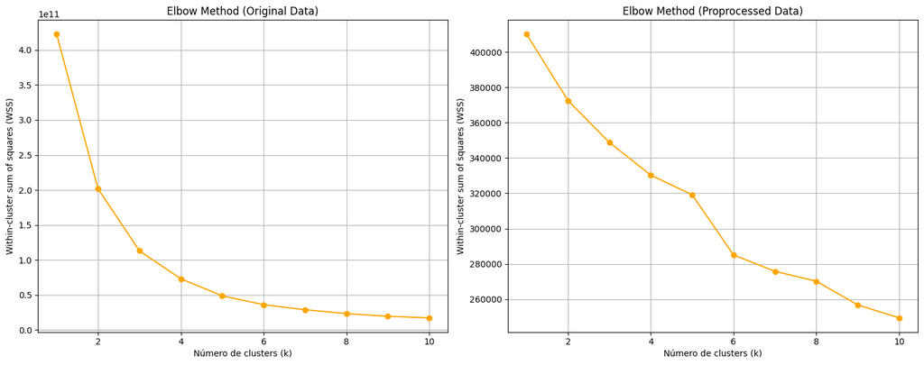

```python
import matplotlib.pyplot as plt

X_original = df_orig_transformado.drop(columns=['y']).values
X_procesado = df_procesado.drop(columns=['y']).values


max_k = 10  # Número máximo de clusters a evaluar

print("Ejecutando el método del codo...")
wss_original = elbow_method(X_original, max_k=max_k)
wss_procesado = elbow_method(X_procesado, max_k=max_k)

# Graficar el método del codo
plt.figure(figsize=(15, 6))
plt.subplot(1, 2, 1)
plt.plot(range(1, max_k + 1), wss_original, marker='o', color='orange')
plt.title("Elbow Method (Original Data)")
plt.xlabel("Número de clusters (k)")
plt.ylabel("Within-cluster sum of squares (WSS)")
plt.grid(True)


# Graficar el método silhoutte
plt.subplot(1, 2, 2)
plt.plot(range(1, max_k + 1), wss_procesado, marker='o', color='orange')
plt.title("Elbow Method (Proprocessed Data)")
plt.xlabel("Número de clusters (k)")
plt.ylabel("Within-cluster sum of squares (WSS)")
plt.grid(True)


plt.tight_layout()
plt.show()
```

Una vez obtenido el número óptimo de clusters según el método del codo, procedemos a realizar la agrupación con K-Means.

```python
from sklearn.cluster import KMeans

k = 4
kmeans_original = KMeans(n_clusters=k, random_state=42)
kmeans_procesado = KMeans(n_clusters=k, random_state=42)
kmeans_original.fit(X_original)
kmeans_procesado.fit(X_procesado)

df_orig_transformado['kmeans'] = kmeans_original.labels_
df_procesado['kmeans'] = kmeans_procesado.labels_

print(f"Etiquetas de clusters para el conjunto original (k={k}):")
print(df_orig_transformado['kmeans'].value_counts())
print(f"\nEtiquetas de clusters para el conjunto procesado (k={k}):")
print(df_procesado['kmeans'].value_counts())
```

```
Etiquetas de clusters para el conjunto original (k=4):
kmeans
0    38686
3     5677
2      796
1       52
Name: count, dtype: int64

Etiquetas de clusters para el conjunto procesado (k=4):
kmeans
0    16893
1    15202
2    11137
3     1979
Name: count, dtype: int64
```

Para hallar el número óptimo de clusters, se ha utilizado el método del codo, no obstante, tambien se pueden utilizar otros métodos. Para la evaluación de los clusters obtenidos a partir de `k-optimo` haremos uso de las siguientes métricas:

- Silhouette Score
- Davies-Bouldin Index
- Calinski-Harabasz Index

```python
from sklearn.metrics import silhouette_score, calinski_harabasz_score, davies_bouldin_score

print(f"Evaluando el modelo KMeans en datos originales (k={k})...")
print("Inercia (SSE):", kmeans_original.inertia_)
print("Silhouette Score:", silhouette_score(X_original, kmeans_original.labels_))
print("Calinski-Harabasz:", calinski_harabasz_score(X_original, kmeans_original.labels_))
print("Davies-Bouldin:", davies_bouldin_score(X_original, kmeans_original.labels_))

print(f"\nEvaluando el modelo KMeans en datos procesados (k={k})...")
print("Inercia (SSE):", kmeans_procesado.inertia_)
print("Silhouette Score:", silhouette_score(X_procesado, kmeans_procesado.labels_))
print("Calinski-Harabasz:", calinski_harabasz_score(X_procesado, kmeans_procesado.labels_))
print("Davies-Bouldin:", davies_bouldin_score(X_procesado, kmeans_procesado.labels_))
```

```
Evaluando el modelo KMeans en datos originales (k=4)...
Inercia (SSE): 73159331666.49121
Silhouette Score: 0.7334733065662904
Calinski-Harabasz: 71972.9031375147
Davies-Bouldin: 0.5208553533700612

Evaluando el modelo KMeans en datos procesados (k=4)...
Inercia (SSE): 330288.96619130264
Silhouette Score: 0.09621241434731469
Calinski-Harabasz: 3640.639967009352
Davies-Bouldin: 2.28386593815147
```

**Conclusiones:**

Recordemos el dataset original determina si un cliente va a contratar el depósito o no (0 o 1). Por lo que podemos observar que aunque el número de clusters óptimo es 4, el dataset original tiene 2 clases. Esto lo conocemos de antemano, en problemas reales la agrupación puede no ser tan claro además de que no tendremos el conocimiento previo de las clases.

A partir de los resultados del modelo KMeans con k=4, podemos observar lo siguiente:

| Métrica | Datos Originales | Datos Procesados | Interpretación Técnica |
| --- | --- | --- | --- |
| **Inercia (SSE)** | 73,159,331,666.49 | 330,288.97 | Menor tras escalar, pero no es comparable directamente porque cambió la escala de las variables |
| **Silhouette Score** | **0.733** | **0.096** | Mucho mejor con datos originales |
| **Calinski-Harabasz** | **71,972.90** | 3,640.64 | Mucho mejor con datos originales |
| **Davies-Bouldin** | **0.521** | 2.284 | Mucho mejor con datos originales (cuanto menor mejor) |

Estos resultados indican:

- La codificación One-Hot + escalado distorsionó las distancias relevantes en el espacio de entrada.
- Tal vez había variables numéricas con significado importante en su escala original (ej. ingresos, edad).
- También puede que las variables categóricas codificadas con One-Hot hayan introducido ruido o creado dimensiones poco informativas.

# 3. Ejercicio 2

K-Medians es un algoritmo de clustering similar a K-Means, pero en lugar de usar la media, utiliza la mediana de cada dimensión como centro del cluster. Minimiza la suma de distancias absolutas (L1), lo que lo hace más robusto frente a outliers que K-Means, aunque puede ser computacionalmente más costoso. No está disponible en `scikit-learn`, haremos uso de `pyclustering`.

```python
from pyclustering.cluster.kmeans import kmeans
from pyclustering.utils.metric import type_metric, distance_metric
import numpy as np
from sklearn.metrics import silhouette_score, calinski_harabasz_score, davies_bouldin_score
import random

def kmedians(X, k):
    manhattan_metric = distance_metric(type_metric.MANHATTAN)
    initial_centroids = [X[i] for i in random.sample(range(len(X)), k)]
    kmedians_instance = kmeans(data=X, initial_centers=initial_centroids, metric=manhattan_metric)
    kmedians_instance.process()
    clusters = kmedians_instance.get_clusters()
    centers = kmedians_instance.get_centers()
    labels_kmedians = np.empty(len(X), dtype=int)
    for i, cluster in enumerate(clusters):
        labels_kmedians[cluster] = i
    return {
        "labels": labels_kmedians,
        "centers": centers
    }

# Convertimos el DataFrame a array
X_original_array = X_original.values if hasattr(X_original, 'values') else X_original
X_procesado_array = X_procesado.values if hasattr(X_procesado, 'values') else X_procesado

kmedians_original = kmedians(X_original_array, k)
kmedians_procesado = kmedians(X_procesado_array, k)

print(f"Evaluando el modelo KMedians en datos originales (k={k})...")
print("Silhouette Score:", silhouette_score(X_original_array, kmedians_original['labels']))
print("Calinski-Harabasz:", calinski_harabasz_score(X_original_array, kmedians_original['labels']))
print("Davies-Bouldin:", davies_bouldin_score(X_original_array, kmedians_original['labels']))

print(f"\nEvaluando el modelo KMedians en datos procesados (k={k})...")
print("Silhouette Score:", silhouette_score(X_procesado_array, kmedians_procesado['labels']))
print("Calinski-Harabasz:", calinski_harabasz_score(X_procesado_array, kmedians_procesado['labels']))
print("Davies-Bouldin:", davies_bouldin_score(X_procesado_array, kmedians_procesado['labels']))
```

```
Evaluando el modelo KMedians en datos originales (k=4)...
Silhouette Score: 0.7336291890761327
Calinski-Harabasz: 71971.13697213592
Davies-Bouldin: 0.5207473577501243

Evaluando el modelo KMedians en datos procesados (k=4)...
Silhouette Score: 0.07751574153435063
Calinski-Harabasz: 2604.461898306063
Davies-Bouldin: 2.852132695442415
```

**Comparativa KMeans vs K-Medians:**

[output not shown]

Comparando KMeans y KMedians sobre datos originales, ambos algoritmos alcanzan métricas de calidad prácticamente idénticas, lo que indica que la estructura del dataset está bien definida y no contiene valores atípicos que justifiquen el uso de medianas.

En contraste, al aplicar los modelos sobre datos procesados (normalizados y codificados), el rendimiento de ambos métodos disminuye notablemente, siendo más acusada la pérdida de calidad en K-Medians. Esto indica que el preprocesamiento ha afectado negativamente la estructura geométrica del dataset, y que la métrica Manhattan no logra capturar adecuadamente la distancia entre los puntos en el nuevo espacio transformado.

# 4. Ejercicio 3

Según la documentación de `scikit-learn`, no es posible cambiar la métrica de distancia en el algoritmo K-Means. Sin embargo, es posible utilizar modificar la función de distancia haciendo uso de `KMeans` de `pyclustering`, que permite utilizar distintas métricas de distancia.

```python
from pyclustering.cluster.kmeans import kmeans
from pyclustering.utils.metric import distance_metric
from pyclustering.cluster.center_initializer import random_center_initializer
from sklearn.metrics import silhouette_score, calinski_harabasz_score, davies_bouldin_score

def kmeans_with_distance(X, k, metric_type=type_metric.EUCLIDEAN):
    metric = distance_metric(metric_type)
    initial_centers = random_center_initializer(X, k, random_state=42).initialize()
    kmeans_instance = kmeans(data=X, initial_centers=initial_centers, metric=metric)
    kmeans_instance.process()
    clusters = kmeans_instance.get_clusters()
    centers = kmeans_instance.get_centers()

    labels_kmeans = np.empty(len(X), dtype=int)
    for i, cluster in enumerate(clusters):
        labels_kmeans[cluster] = i
    return {
        "labels": labels_kmeans,
        "centers": centers
    }

# Convertimos el DataFrame a array
X_original_array = X_original.values if hasattr(X_original, 'values') else X_original
X_procesado_array = X_procesado.values if hasattr(X_procesado, 'values') else X_procesado

metric_type = type_metric.MANHATTAN  # Usamos la métrica Manhattan para KMedians
metric_name = type_metric(metric_type).name
kmeans_custom_metric_original = kmeans_with_distance(X_original_array, k, metric_type)
kmeans_custom_metric_procesado = kmeans_with_distance(X_procesado_array, k, metric_type)


print(f"Evaluando el modelo KMeans con distancia {metric_name} en datos originales (k={k})...")
print("Silhouette Score:", silhouette_score(X_original_array, kmeans_custom_metric_original['labels']))
print("Calinski-Harabasz:", calinski_harabasz_score(X_original_array, kmeans_custom_metric_original['labels']))
print("Davies-Bouldin:", davies_bouldin_score(X_original_array, kmeans_custom_metric_original['labels']))

print(f"\nEvaluando el modelo KMeans con distancia {metric_name} en datos procesados (k={k})...")
print("Silhouette Score:", silhouette_score(X_procesado_array, kmeans_custom_metric_procesado['labels']))
print("Calinski-Harabasz:", calinski_harabasz_score(X_procesado_array, kmeans_custom_metric_procesado['labels']))
print("Davies-Bouldin:", davies_bouldin_score(X_procesado_array, kmeans_custom_metric_procesado['labels']))
```

```
Evaluando el modelo KMeans con distancia MANHATTAN en datos originales (k=4)...
Silhouette Score: 0.7336291890761327
Calinski-Harabasz: 71971.13697213592
Davies-Bouldin: 0.5207473577501243

Evaluando el modelo KMeans con distancia MANHATTAN en datos procesados (k=4)...
Silhouette Score: 0.08246224001604602
Calinski-Harabasz: 2894.6276042118657
Davies-Bouldin: 2.7311848297980292
```

**Comparativa KMeans con distintas métricas:**

[output not shown]

Se observa que los resultados obtenidos al aplicar KMeans utilizando la distancia Manhattan (simulada mediante K-Medians o K-Medoids) en el conjunto original son prácticamente idénticos a los de KMeans clásico con distancia Euclídea, tanto en cohesión como en separación entre clusters.

En cambio, los resultados en el conjunto procesado (con variables codificadas y normalizadas) presentan un descenso significativo de la calidad del clustering en todos los modelos, siendo más pronunciado en los modelos basados en Manhattan.

# 5. Ejercicio 4

Aplicaremos a continuación el algoritmo `DBSCAN` (Density-Based Spatial Cluestering of Applications with Noise). Los dos hiperparámetros principales de este algoritmo son:

- El hiperparámetro `eps` define la distancia máxima entre dos puntos para que se consideren parte del mismo cluster. Se puede calcular utilizando gráficos de distancias.
- El hiperparámetro `min_samples` define el número mínimo de puntos necesarios para formar un cluster. Por normal general suele ser $\text{min\_samples} = 2 * \text{dimensiones}$, aunque se puede ajustar según el caso. En nuestro ejemplo será 10, ya que el dataset tiene múltiples dimensiones.

Hallemos los hipérparámetros para DBSCAN para ambos datasets:

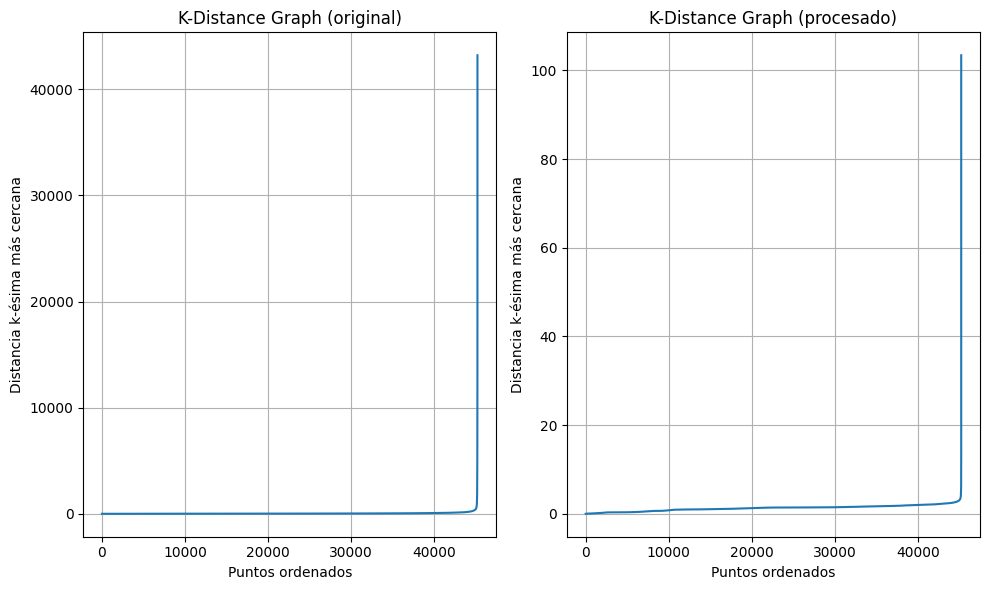

```python
from sklearn.neighbors import NearestNeighbors
import numpy as np

X_original, y_original = df_orig_transformado.drop(columns=['y']), df_orig_transformado['y']
X_procesado, y_procesado = df_procesado.drop(columns=['y']), df_procesado['y']

def get_distances(X, min_samples):
    neighbors = NearestNeighbors(n_neighbors=min_samples)
    neighbors.fit(X)
    distances, indices = neighbors.kneighbors(X)
    return np.sort(distances[:, -1])

min_samples = 10  # Regla general para DBSCAN


sorted_distances_original = get_distances(X_original, min_samples)
sorted_distances_procesado = get_distances(X_procesado, min_samples)

plt.figure(figsize=(10, 6))
plt.subplot(1, 2, 1)
plt.plot(sorted_distances_original, linestyle='-')
plt.title('K-Distance Graph (original)')
plt.xlabel("Puntos ordenados")
plt.ylabel("Distancia k-ésima más cercana")
plt.grid(True)

plt.subplot(1, 2, 2)
plt.plot(sorted_distances_procesado, linestyle='-')
plt.title('K-Distance Graph (procesado)')
plt.xlabel("Puntos ordenados")
plt.ylabel("Distancia k-ésima más cercana")
plt.grid(True)

plt.tight_layout()
plt.show()
```

```python
from sklearn.cluster import DBSCAN

dbscan_original = DBSCAN(eps=2000, min_samples=min_samples)
dbscan_procesado = DBSCAN(eps=3, min_samples=min_samples)

dbscan_original_labels = dbscan_original.fit_predict(X_original)
dbscan_procesado_labels = dbscan_procesado.fit_predict(X_procesado)

df_orig_transformado['dbscan'] = dbscan_original_labels
df_procesado['dbscan'] = dbscan_procesado_labels

print("Etiquetas de clusters para el conjunto original (DBSCAN):")
print(df_orig_transformado['dbscan'].value_counts())

print("\nEtiquetas de clusters para el conjunto procesado (DBSCAN):")
print(df_procesado['dbscan'].value_counts())
```

```
Etiquetas de clusters para el conjunto original (DBSCAN):
dbscan
 0    45167
-1       32
 1       12
Name: count, dtype: int64

Etiquetas de clusters para el conjunto procesado (DBSCAN):
dbscan
 0    45113
-1       98
Name: count, dtype: int64
```

En el conjunto original: DBSCAN ha identificado un gran cluster principal (0) con la mayoría de los puntos (45,167), mientras que solo un pequeño número de puntos (32) ha sido clasificado como ruido (etiqueta -1). Además, hay un pequeño grupo (12 puntos) que se ha clasificado en un segundo cluster (1), lo que indica que DBSCAN pudo identificar una pequeña estructura adicional en los datos.

Estos resultados resaltan cómo el preprocesamiento puede alterar la capacidad del algoritmo para detectar clusters reales, ya que los datos procesados aumentan la heterogeneidad de las distancias entre los puntos, haciendo más difícil identificar patrones consistentes. Además, DBSCAN demuestra ser sensible al preprocesamiento al aumentar el número de puntos clasificados como ruido en el conjunto procesado.

Pasemos ahora a realizar las mediciones de calidad del clustering obtenido con DBSCAN para ambos datasets:

```python
from sklearn.metrics import silhouette_score, calinski_harabasz_score, davies_bouldin_score

mask_original = dbscan_original_labels != -1
mask_procesado = dbscan_procesado_labels != -1

print("Evaluando el modelo DBSCAN (eps=2000 y min_values=10) en datos originales...")
print("Silhouette Score:", silhouette_score(X_original[mask_original], dbscan_original_labels[mask_original]))
print("Calinski-Harabasz:", calinski_harabasz_score(X_original[mask_original], dbscan_original_labels[mask_original]))
print("Davies-Bouldin:", davies_bouldin_score(X_original[mask_original], dbscan_original_labels[mask_original]))

print("\nEvaluando el modelo DBSCAN (eps=3 y min_values=10) en datos procesados...")
print("Silhouette Score: Imposible de calcular, no tenemos más de 2 clusteres")
print("Calinski-Harabasz: Imposible de calcular, no tenemos más de 2 clusteres")
print("Davies-Bouldin: Imposible de calcular, no tenemos más de 2 clusteres")
```

```
Evaluando el modelo DBSCAN (eps=2000 y min_values=10) en datos originales...
Silhouette Score: 0.9358055023715218
Calinski-Harabasz: 2227.7841953151974
Davies-Bouldin: 0.06645203513230628

Evaluando el modelo DBSCAN (eps=3 y min_values=10) en datos procesados...
Silhouette Score: Imposible de calcular, no tenemos más de 2 clusteres
Calinski-Harabasz: Imposible de calcular, no tenemos más de 2 clusteres
Davies-Bouldin: Imposible de calcular, no tenemos más de 2 clusteres
```

**Comparación Modelos no supervisados: KMeans, KMedians y DBSCAN**

[output not shown]

DBSCAN mostró un excelente desempeño en los datos originales, identificando clusters bien definidos con alta cohesión y separación (Silhouette ≈ 0.94 y Davies-Bouldin muy bajo), además de detectar eficazmente el ruido. Sin embargo, en los datos procesados, el algoritmo no pudo formar más de un cluster significativo, lo que impidió evaluar su calidad y refleja que la normalización y codificación afectaron negativamente la estructura de densidad necesaria para su buen funcionamiento.

# 6. Ejercicio 5

Para evaluar la capacidad del modelo de generalizar a datos no vistos, se ha dividido el conjunto de datos en dos subconjuntos:

- **Conjunto de entrenamiento (train)**: se utilizará para ajustar el modelo de clasificación.
- **Conjunto de test**: se utilizará exclusivamente para evaluar el rendimiento del modelo sobre datos no vistos.

La división se ha realizado mediante la función `train_test_split` de `scikit-learn`, utilizando una separación estratificada (en caso de clasificación supervisada) para preservar la distribución de las clases:

```python
from sklearn.model_selection import train_test_split

X, y = df_procesado.drop(columns=['y']), df_procesado['y']


X_train, X_test, y_train, y_test = train_test_split(
    X, y, test_size=0.3, random_state=42, stratify=y
)
```

Se ha utilizado una división 70% para entrenamiento y 30% para test, ya que esta proporción es ampliamente aceptada como equilibrio entre:

- Tener suficiente información para **entrenar el modelo** de forma robusta.
- Reservar una porción representativa para **validar su capacidad de generalización**.

Además, al disponer de un conjunto de datos con un número considerable de muestras (p.ej., más de 10.000), esta partición asegura que **ambos subconjuntos contengan suficiente información estadística**, sin comprometer ni el aprendizaje ni la evaluación.

En escenarios donde los datos son limitados o se aplican técnicas más avanzadas (como validación cruzada), podrían ajustarse estas proporciones, pero para este caso concreto la división 70/30 es adecuada y proporciona una evaluación fiable del modelo.

# 7. Ejercicio 6

Realizaremos el entrenamiento del árbol de decisión utilizando el conjunto de entrenamiento y evaluaremos su rendimiento en el conjunto de test. Nos apoyaremos en la clase `DecisionTreeClassifier` de `scikit-learn` para construir el modelo. Definiremos la profundidad del árbol de decisión en 4 para evitar sobreajuste.

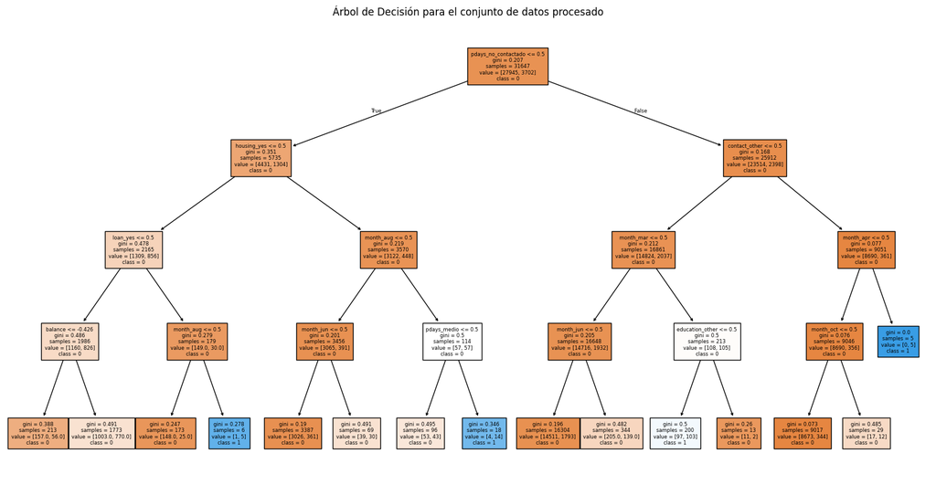

```python
from sklearn.tree import DecisionTreeClassifier, plot_tree

clf = DecisionTreeClassifier(random_state=42, max_depth=4)
clf.fit(X_train, y_train)

plt.figure(figsize=(20, 10))
plot_tree(clf, feature_names=X.columns, class_names=[str(cls) for cls in clf.classes_], filled=True, fontsize=6)
plt.title("Árbol de Decisión para el conjunto de datos procesado")
plt.show()
```

Exportamos las reglas en formato texto:

```python
from sklearn.tree import export_text

tree_rules = export_text(clf, feature_names=list(X.columns))
print("Reglas del árbol de decisión:")
print(tree_rules)
```

```
Reglas del árbol de decisión:
|--- pdays_no_contactado <= 0.50
|   |--- housing_yes <= 0.50
|   |   |--- loan_yes <= 0.50
|   |   |   |--- balance <= -0.43
|   |   |   |   |--- class: 0
|   |   |   |--- balance >  -0.43
|   |   |   |   |--- class: 0
|   |   |--- loan_yes >  0.50
|   |   |   |--- month_aug <= 0.50
|   |   |   |   |--- class: 0
|   |   |   |--- month_aug >  0.50
|   |   |   |   |--- class: 1
|   |--- housing_yes >  0.50
|   |   |--- month_aug <= 0.50
|   |   |   |--- month_jun <= 0.50
|   |   |   |   |--- class: 0
|   |   |   |--- month_jun >  0.50
|   |   |   |   |--- class: 0
|   |   |--- month_aug >  0.50
|   |   |   |--- pdays_medio <= 0.50
|   |   |   |   |--- class: 0
|   |   |   |--- pdays_medio >  0.50
|   |   |   |   |--- class: 1
|--- pdays_no_contactado >  0.50
|   |--- contact_other <= 0.50
|   |   |--- month_mar <= 0.50
|   |   |   |--- month_jun <= 0.50
|   |   |   |   |--- class: 0
|   |   |   |--- month_jun >  0.50
|   |   |   |   |--- class: 0
|   |   |--- month_mar >  0.50
|   |   |   |--- education_other <= 0.50
|   |   |   |   |--- class: 1
|   |   |   |--- education_other >  0.50
|   |   |   |   |--- class: 0
|   |--- contact_other >  0.50
|   |   |--- month_apr <= 0.50
|   |   |   |--- month_oct <= 0.50
|   |   |   |   |--- class: 0
|   |   |   |--- month_oct >  0.50
|   |   |   |   |--- class: 0
|   |   |--- month_apr >  0.50
|   |   |   |--- class: 1
```

Se muestran a continuación las características más relevantes:

```python
import pandas as pd
important = pd.Series(clf.feature_importances_, index=X.columns).sort_values(ascending=False)
print(important.head())
```

```
housing_yes            0.292764
pdays_no_contactado    0.254586
contact_other          0.115029
month_jun              0.108623
month_mar              0.089100
dtype: float64
```

**Características más relevantes del árbol de decisión:**

Clientes con préstamo hipotecario (housing_yes = 1) tienen una probabilidad diferente de pertenecer a cierta clase. La ausencia de contacto previo (pdays_no_contactado) influye en la predicción, diferenciando grupos con distintos historiales de interacción. El tipo y el momento del contacto también modelan la respuesta del cliente, mostrando la importancia de la estrategia temporal y del canal utilizado.

**Matriz de confusión:**

Procedemos a mostrar la matriz de confusión para evaluar el rendimiento del modelo en el conjunto de test:

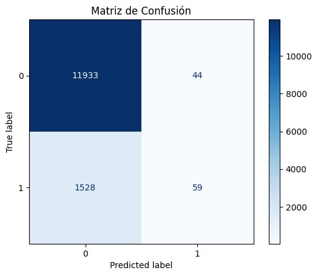

```
Métricas del modelo con poda:
Accuracy: 0.8841049837805957
Precision: 0.5728155339805825
Recall: 0.037177063642092
F1 Score: 0.06982248520710059
ROC AUC Score: 0.5167516778509367
Balanced Accuracy: 0.5167516778509367
```

```python
from sklearn.metrics import (
    accuracy_score,
    precision_score,
    recall_score,
    f1_score,
    confusion_matrix,
    ConfusionMatrixDisplay,
    roc_auc_score,
    balanced_accuracy_score,
)

predictions = clf.predict(X_test)

cm = confusion_matrix(y_test, predictions, labels=clf.classes_)
disp = ConfusionMatrixDisplay(confusion_matrix=cm, display_labels=clf.classes_)
disp.plot(cmap='Blues')
plt.title("Matriz de Confusión")
plt.show()

print("Métricas del modelo con poda:")
print("Accuracy:", accuracy_score(y_test, predictions))
print("Precision:", precision_score(y_test, predictions))
print("Recall:", recall_score(y_test, predictions))
print("F1 Score:", f1_score(y_test, predictions))
print("ROC AUC Score:", roc_auc_score(y_test, predictions, average='weighted'))
print("Balanced Accuracy:", balanced_accuracy_score(y_test, predictions))
```

Creemos un segundo Arbol de Decisión, sin realizar ningún tipo de poda

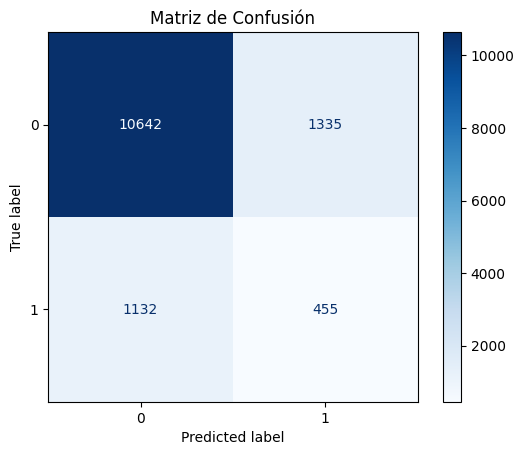

```
Métricas del modelo sin poda:
Accuracy: 0.8181214980831613
Precision: 0.2541899441340782
Recall: 0.2867044738500315
F1 Score: 0.2694699437370447
ROC AUC Score: 0.5876204176046517
Balanced Accuracy: 0.5876204176046518
```

```python
from sklearn.tree import DecisionTreeClassifier
from sklearn.metrics import (
    accuracy_score,
    precision_score,
    recall_score,
    f1_score,
    confusion_matrix,
    ConfusionMatrixDisplay,
    roc_auc_score,
    balanced_accuracy_score,
)

clf_raw = DecisionTreeClassifier(random_state=42)
clf_raw.fit(X_train, y_train)

predictions_raw = clf_raw.predict(X_test)

cm = confusion_matrix(y_test, predictions_raw, labels=clf.classes_)
disp = ConfusionMatrixDisplay(confusion_matrix=cm, display_labels=clf.classes_)
disp.plot(cmap='Blues')
plt.title("Matriz de Confusión")
plt.show()

print("Métricas del modelo sin poda:")
print("Accuracy:", accuracy_score(y_test, predictions_raw))
print("Precision:", precision_score(y_test, predictions_raw))
print("Recall:", recall_score(y_test, predictions_raw))
print("F1 Score:", f1_score(y_test, predictions_raw))
print("ROC AUC Score:", roc_auc_score(y_test, predictions_raw, average='weighted'))
print("Balanced Accuracy:", balanced_accuracy_score(y_test, predictions_raw))
```

**Comparación Árbol de Desición con y sin poda:**

| Métrica | Sin Poda | Con Poda |
| --- | --- | --- |
| **Accuracy** | 0.8181 | 0.8841 |
| **Precision** | 0.2542 | 0.5728 |
| **Recall** | 0.2867 | 0.0372 |
| **F1 Score** | 0.2695 | 0.0698 |
| **ROC AUC Score** | 0.5876 | 0.5168 |
| **Balanced Accuracy** | 0.5876 | 0.5168 |

Sin poda, el modelo tiene un rendimiento razonable en cuanto a precisión y recall, pero con una mayor capacidad de identificar positivos (recall), aunque no siempre de manera precisa. Su F1 Score refleja ese compromiso entre precisión y recall.

Con poda, el modelo mejora en precisión (prediciendo más correctamente los positivos), pero a costa de una gran disminución en recall y F1 Score. Aunque el accuracy aumenta, esto es engañoso debido a un fuerte desequilibrio entre las clases y la pérdida de la capacidad de identificar todos los casos positivos.

La elección entre poda o sin poda dependerá del contexto del problema y los objetivos que se quieren alcanzar. Si el modelo debe priorizar no perder casos positivos (por ejemplo, en detección de fraude o enfermedades), el modelo sin poda será más adecuado. Si, por el contrario, se busca un modelo más seguro que minimice los falsos positivos (aunque perdiendo muchos verdaderos positivos), la poda podría ser útil, pero se deben explorar otros ajustes para evitar la pérdida de precisión.

# 8. Ejercicio 7

Dado que estamos ante un problema de clasificación binaria con un desajuste significativo entre las clases, haremos uso del algoritmo `AdaBoostClassifier` de `scikit-learn`, que es un algoritmo de boosting que combina múltiples clasificadores débiles para crear un modelo más robusto y es especialmente útil en problemas con clases desbalanceadas.

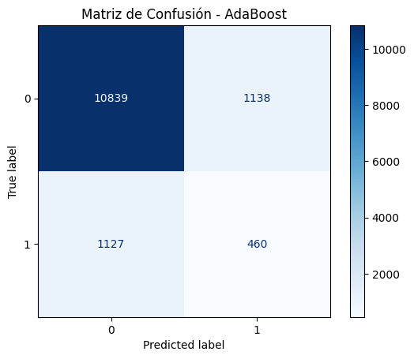

```
Métricas del modelo AdaBoost:
Accuracy: 0.8330138602182248
Precision: 0.2878598247809762
Recall: 0.2898550724637681
F1 Score: 0.28885400313971743
ROC AUC Score: 0.5974198130958733
Balanced Accuracy: 0.5974198130958733
```

```python
from sklearn.ensemble import AdaBoostClassifier
from sklearn.tree import DecisionTreeClassifier
from sklearn.metrics import (
    accuracy_score,
    precision_score,
    recall_score,
    f1_score,
    confusion_matrix,
    ConfusionMatrixDisplay,
    roc_auc_score,
    balanced_accuracy_score,
)

ada = AdaBoostClassifier(
    estimator=DecisionTreeClassifier(random_state=42),
    n_estimators=50,
    random_state=42
)

ada.fit(X_train, y_train)

predictions_ada = ada.predict(X_test)

cm_ada = confusion_matrix(y_test, predictions_ada, labels=clf.classes_)
disp_ada = ConfusionMatrixDisplay(confusion_matrix=cm_ada, display_labels=clf.classes_)
disp_ada.plot(cmap='Blues')
plt.title("Matriz de Confusión - AdaBoost")
plt.show()

print("Métricas del modelo AdaBoost:")
print("Accuracy:", accuracy_score(y_test, predictions_ada))
print("Precision:", precision_score(y_test, predictions_ada))
print("Recall:", recall_score(y_test, predictions_ada))
print("F1 Score:", f1_score(y_test, predictions_ada))
print("ROC AUC Score:", roc_auc_score(y_test, predictions_ada, average='weighted'))
print("Balanced Accuracy:", balanced_accuracy_score(y_test, predictions_ada))
```

**Comparación de modelos: Árbol de Decisión vs AdaBoost**

| Métrica | Árbol de Decisión (sin poda) | Árbol de Decisión (con poda) | AdaBoost |
| --- | --- | --- | --- |
| **Accuracy** | 0.8181 | 0.8841 | 0.8330 |
| **Precision** | 0.2542 | 0.5728 | 0.2879 |
| **Recall** | 0.2867 | 0.0372 | 0.2899 |
| **F1 Score** | 0.2695 | 0.0698 | 0.2889 |
| **ROC AUC Score** | 0.5876 | 0.5168 | 0.5974 |
| **Balanced Accuracy** | 0.5876 | 0.5168 | 0.5974 |

# 9. Ejercicio 8

**Limitaciones del conjunto de datos seleccionado (Bank Marketing):**

1. **Desbalanceo de clases**: Según observamos en la práctica 1, el desbalanceo entre clases es muy significativo, lo que puede llevar a modelos que favorezcan la clase mayoritaria y no generalicen bien para la minoritaria.
   1. **Impacto en modelos no supervisados**: Estos modelos pueden no identificar correctamente las estructuras subyacentes de la clase minoritaria y podrían llegar a ser clasificados como ruido.
   2. **Impacto en modelos supervisados**: En estos modelos podríamos tener un `accuracy` alto, como hemos podido comprobar, pero con un `recall` y `precision` muy bajos para la clase minoritaria, lo que indica que el modelo no está aprendiendo correctamente a identificar los casos de interés.
2. **Presencia de variables categóricas con muchas categorías**: Algunas variables categóricas (`job`, `education`, `maritial`, `contact`) tienen muchas categorías, lo que puede complicar la codificación y aumentar la dimensionalidad del conjunto de datos, afectando el rendimiento de los modelos.
   1. **Impacto en modelos no supervisados**: Las variables categóricas no suelen ser favorables trabajando con la distancia euclídea en KMeans y transformarlas en numéricas pueden distorsionar el modelo.
   2. **Impacto en modelos supervisados**: Un gran número de categorías puede llevar a aumentar excesivamente la dimensionalidad del espacio de características, ocasionando un sobreajuste o un rendimiento ineficiente del modelo.
3. **Información sesgada (duration)**: En este ejemplo, duration es una variable que está sesgada según la documentación del dataset (duration=0 -> y=0).

**Riesgos asociados a los modelos de aprendizaje supervisado:**

**Conclusiones finales:**

Durante el desarrollo de esta práctica se ha llevado a cabo la aplicación de diversas técnicas de minería de datos, abarcando tanto métodos supervisados como no supervisados, utilizando como base el conjunto de datos denominado “Bank Marketing” proveniente del repositorio UCI Machine Learning Repository. El principal propósito ha sido evaluar la efectividad predictiva de diferentes algoritmos.

Por otro lado, en el ámbito del aprendizaje supervisado, se han entrenado y evaluado dos modelos principales: un árbol de decisión y un modelo de ensamble basado en AdaBoost. Si bien ambos algoritmos alcanzan niveles aceptables de precisión global (accuracy), métricas complementarias como la precisión (precision), la exhaustividad (recall) y la puntuación F1 (f1-score) ponen de manifiesto que estos modelos presentan dificultades para identificar correctamente la clase minoritaria, que en este contexto representa a los clientes que efectivamente contratan un producto financiero. Este comportamiento es coherente con el fuerte desequilibrio presente en la distribución de clases del dataset, limitando la capacidad de generalización del modelo y su efectividad para detectar casos positivos con relevancia práctica.

En definitiva, esta práctica permite comprender la utilidad de distintos enfoques en aprendizaje automático, así como la necesidad de adaptar las técnicas al contexto del problema. Se destaca que, en problemas reales con datos desbalanceados, el uso de métricas alternativas al accuracy, el preprocesamiento riguroso y la interpretación del dominio del problema son claves para construir modelos útiles y éticamente responsables.